# Impact of Adaptive Traffic Signal System on Travel Time Reliability: Analysis Using Bayesian Additive Regression Model

Emmanuel Kidando & John Kodi

Aug, 2020

## Highlights

### *Adaptive signal control technology (ASCT) is a system that dynamically and automatically adjusts signal timing parameters in real-time to optimize traffic operations of a corridor.*

### We develop a stochastic model to ascertain the mobility effect of the ASCT on travel time reliability (TTR).

### TTR performance metrics based on the measure of variations (coefficient of variation) and index-based measures (buffer index, planning time index, and misery index) were used in the analysis.

### The stochastic model proposed is based on Bayesian additive regression, which its parameters are specified as distributions.

### Travel time data of a 3.3-mile corridor on Mayport highway in Jacksonville, Florida was used as the case study.

# Introduction

### We introduce a novel statistical model for quantifying the mobility benefit of ASCT in terms of TTR

### The analysis is based on a Bayesian additive regression model with a change-point assumption to calibrate the travel time with and without the ASCT system

### Markov Chain Monte Carlo simulations implemented in pymc3, a python package, were used to calibrate the posterior distributions

### Data used in the model were gathered from an arterial highway located in Florida

### Data are collected at 5 min interval

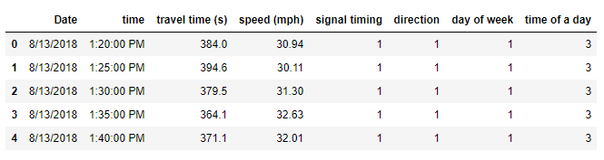

Time Series Plot of Travel Time Data

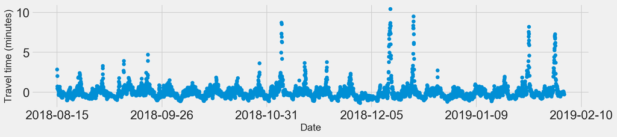

### A sinusoidal function based on a Fourier Series can accurately approximate this pattern

## Methodology

$$y_{t} \sim N(\mu_{t}, \sigma^2)$$
$$\mu_{t} = f_1(x_{t}) \text { if } t \leq \tau$$
$$\mu_{t} = f_2(x_{t}) \text { if } t > \tau$$

### where,

$$f_1(x_{t}) = \beta_{10}+\sum_{n=1}^{N}\beta_{1n}cos(n\omega_{1n}x_{t}+\phi_{1n})$$
$$f_2(x_{t}) = \beta_{20}+\sum_{n=1}^{N}\beta_{2n}cos(n\omega_{2n}x_{t}+\phi_{2n})$$

### The model in python

```
with pm.Model() as Fourier_series_model:

    amp_with_0 = pm.Normal("amp_with_0", mu=0, sd=10)
    amp_with_1 = pm.Normal("amp_with_1", mu=0, sd=10)



    amp_withou_0 = pm.Normal("amp_withou_0", mu=0, sd=10)
    amp_withou_1 = pm.Normal("amp_withou_1", mu=0, sd=10)



    phi_with_0 = pm.Gamma("phi_with_0", 1, 1)
    phi_with_1 = pm.Gamma('phi_with_1', 1, 1)



    phi_withou_0 = pm.Gamma("phi_withou_0", 1, 1)
    phi_withou_1 = pm.Gamma('phi_withou_1', 1, 1)


    phase_with_0 = pm.Uniform('phase_with_0', -np.pi/2, np.pi/2)
    phase_with_1 = pm.Uniform('phase_with_1', -np.pi/2, np.pi/2)



    phase_withou_0 = pm.Uniform('phase_withou_0', -np.pi/2, np.pi/2)
    phase_withou_1 = pm.Uniform('phase_withou_1', -np.pi/2, np.pi/2)



    β0 = pm.Normal("β0", mu=0, sd=10)
    α0 = pm.Normal("α0", mu=0, sd=5)

    σ_1 = pm.HalfNormal('σ_1', sd=0.5)
    σ_2 = pm.HalfNormal('σ_2', sd=0.5)

    μ11 = (amp_with_0 * T.cos(1 * phi_with_0 * tt + phase_with_0) +
           amp_with_1 * T.cos(2 * phi_with_1 * tt + phase_with_1)
          )

    μ12 = (amp_withou_0 * T.cos(1 * phi_withou_0 * tt + phase_withou_0) +
           amp_withou_1 * T.cos(2 * phi_withou_1 * tt + phase_withou_1)
          )

    mu_1 = α0 + μ11
    mu_2 = β0 + μ12

    tau = pm.DiscreteUniform('tau', lower=0, upper = tt.max())

    sd = pm.math.switch(tau > tt, σ_1, σ_2)
    μ =  pm.math.switch(tau > tt, mu_1, mu_2)


    # likelihood and sampling
    observation = pm.Normal('observation', mu= μ, sd= sd, observed=Y)
```

## Graphical Posterior Predictive Checks

### Graphical displays of actual and predicted samples ([ref](https://stat.columbia.edu/~gelman/presentations/ggr.pdf))

### For a good model, predicted and actual data should look the same

### The posterior distribution can be estimated as follows:

$$p(y^{pred}|y) = \int p(y^{pred}|\theta, y)p(\theta|y)d\theta$$

### In python pymc3 package, the above estimation is done as follows:

```
with Fourier_series_model:
    pred_samples = pm.sample_posterior_predictive(trace, samples=1000)
```

Actual Data and Posterior Predicted lines

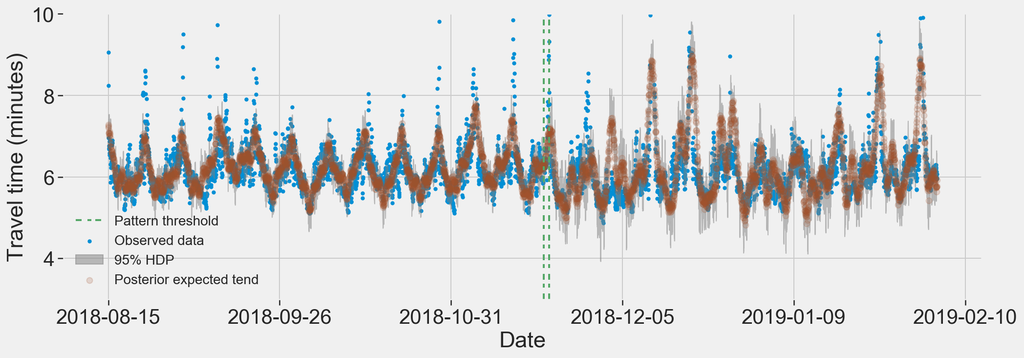

Actual Data and Posterior Predicted Density

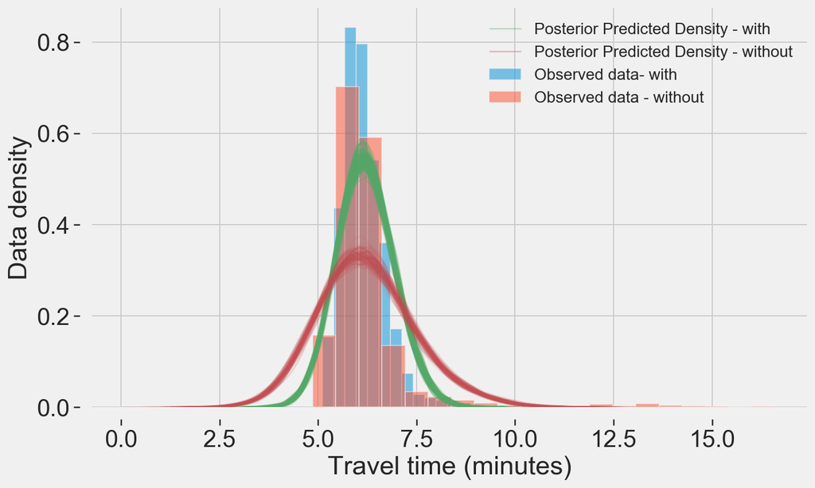

### For Thursday data, the variation after the pattern threshold line is higher than before the line (see 95% HDI)

### Similar findings can be seen on the plot of density

## Travel Time Reliability (TTR)

### Four travel time reliability metrics were computed from the posterior distributions

### Coefficient of variation, buffer index, misery index and planning time index

### Here is a python code to compute the four above TTR metrics:

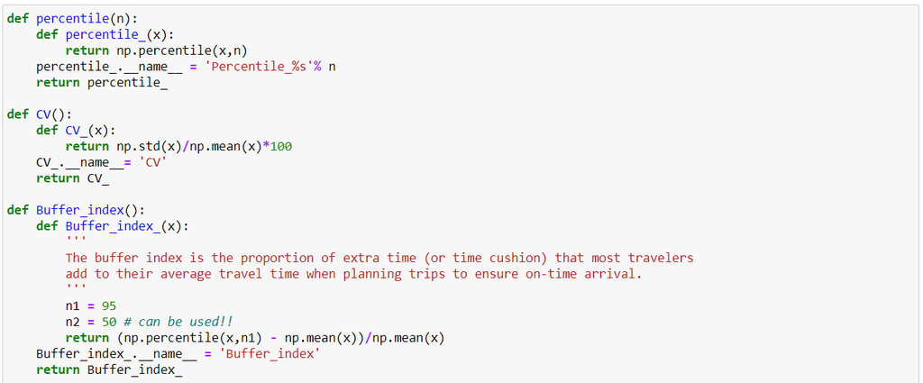

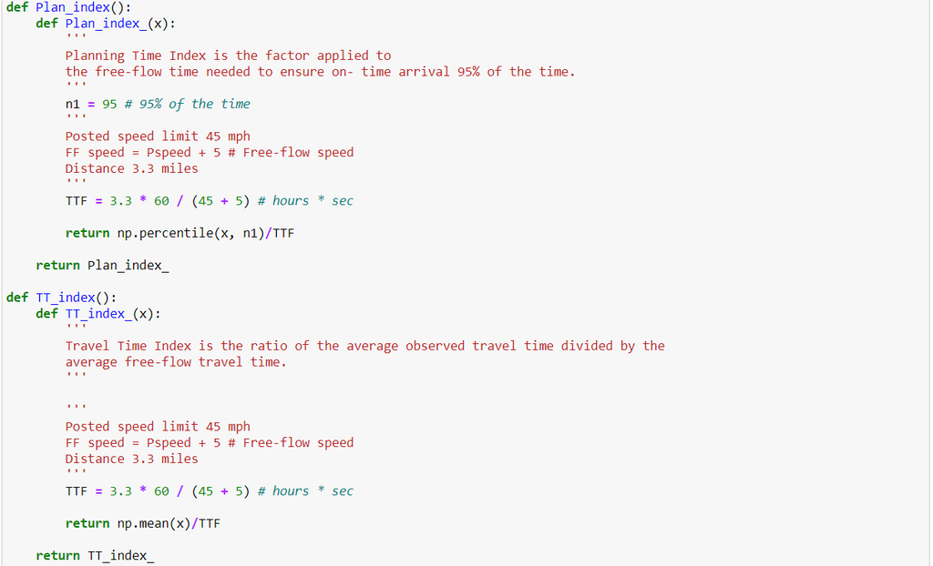

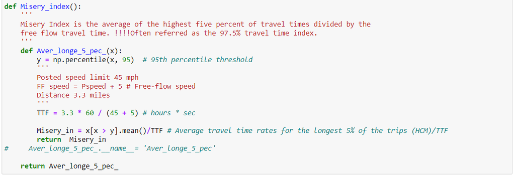

Posterior Distributions of Travel Time Reliability Metrics

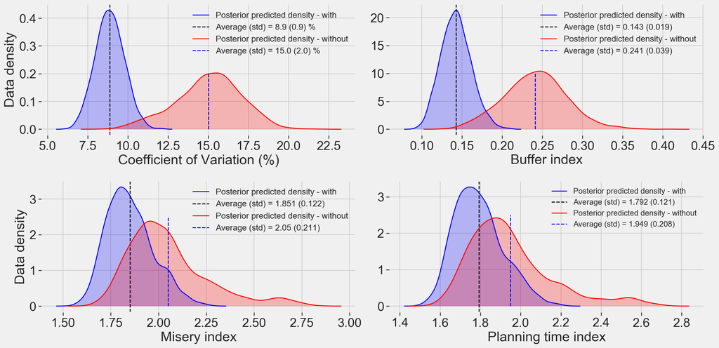

### Generally, the predicted posterior distributions of the TTR above indicate that without ASCT system the coefficient of variation, buffer index, misery index and planning time index are higher than with the ASCT operating

### The coefficient of variation quantifies the speed or travel time variation in the study corridor. Traffic engineers would prefer reducing travel speed variation for safety and operational reasons.

### Buffer index on the other hand estimates the extra time that traveler use beyond the average travel time. Similarly, the ASTC reduces this metric, which is good.

### Misery index looks at the highest 5th percentile travel times in the study corridor. A smaller index means better operating speed over a large index.

### Based on the findings above, we can say that ASCT improves the TTR of the study corridor.

### The fundamental question though, does the improvement statistically significant?

# Let us evaluate the posterior difference of these metrics between with and without ASTC

### We can use the Highest density interval (HDI) to summarize the posterior distribution differences and make a discrete conclusion about the analysis

### If the HDI does not cross zero, we can say the difference between with and without ASCT in travel time reliability is statistically significant.

### Python code for computing HDI

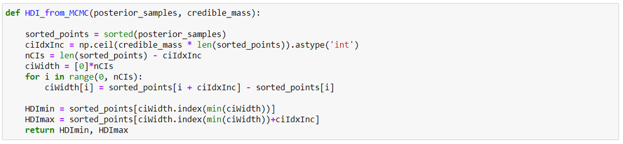

Posterior Density of TTR Difference

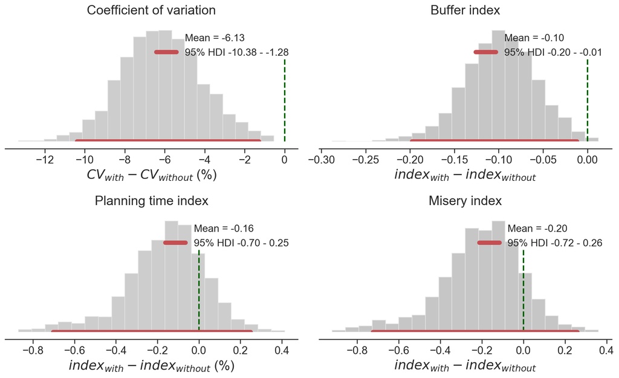

### We can see that there are significant differences at 95% HDI between with and without ASCT coefficient of variation and buffer index

### On the other hand, no significant differences are observed in the planning time and misery index.

### Looking at the coefficient of variation difference, with the ASCT the speed or travel time variation decreases compared to without the ASCT. The average difference in coefficient of variations is around -6%

### For the buffer index, ASCT reduced the index estimate compared to when the ASCT is not operating (the average difference is -0.10)

## Conclusions

### The analysis reveals that deploying the ASCT system improves travel time reliability (TTR)

### Metrics to quantify the TTR used are coefficient of variation, buffer index, planning time index, and misery index.

### Out of the four metrics, two metrics were found to have a significant difference between with and without the ASCT at 95% highest density interval

### Note that the analysis presented herein considered only one day (Thursday) data were used in the analysis

## References

### Graphical posterior predictive checks using the bayesplot package ([ref](https://cran.r-project.org/web/packages/bayesplot/vignettes/graphical-ppcs.html#graphical-posterior-predictive-checks-ppcs))

### Highway Capacity Manual 2016

### Assessment of Factors Associated with Travel Time Reliability and Prediction: An Empirical Analysis Using Probabilistic Reasoning Approach ([ref](https://www.tandfonline.com/doi/abs/10.1080/03081060.2019.1600239?journalCode=gtpt20))

### Prophet: forecasting at scale ([ref](https://research.fb.com/blog/2017/02/prophet-forecasting-at-scale/))